# English 2018 D-Linking

Alex Kramer

4/10/2020

## Data

First, we load in the ’18 data. There are some big issues with the data (multiple zscores are `NA`, about half of the data has no information for items), so some serious cleanup is warranted.

```r
df.english <- read.delim("Eng18.txt")


df.english <- df.english %>%
  drop_na() %>%
  filter(Age != "18. This is me, Alex.") %>% # Remove NAs and other weird things
  select(participant, condition, response, zscore, list, stimuli2, stimuli3) %>%
  mutate(filler=ifelse(grepl("f", condition, fixed=TRUE), 1, 0)) %>% # Binary coding for filler/not filler
  rename("itemN"=stimuli2, "itemText" = stimuli3)

df.english$condition   <- factor(df.english$condition)
df.english$participant <- factor(df.english$participant)
df.english$list        <- factor(df.english$list)
df.english$itemN       <- factor(df.english$itemN)

head(df.english, 50)
```

```
##    participant condition response      zscore list itemN itemText filler
## 1            4  LongBare        7  0.85371841    1   181     Beth      0
## 2            4  LongBare        7  0.85371841    1   182     Mike      0
## 3            4  LongBare        7  0.85371841    1   183      Jen      0
## 4            4  LongBare        2 -2.14726687    1   184     Jake      0
## 5            9  LongBare        5 -0.04094759    1   181     Beth      0
## 6            9  LongBare        5 -0.04094759    1   183      Jen      0
## 7            9  LongBare        5 -0.04094759    1   184     Jake      0
## 8            9  LongBare        4 -0.60738922    1   182     Mike      0
## 9           13  LongBare        7  1.35470774    1   181     Beth      0
## 10          13  LongBare        7  1.35470774    1   182     Mike      0
## 11          13  LongBare        7  1.35470774    1   183      Jen      0
## 12          13  LongBare        7  1.35470774    1   184     Jake      0
## 13          19  LongBare        5  0.55654320    1   183      Jen      0
## 14          19  LongBare        4  0.09185664    1   181     Beth      0
```

[output cut: 36 more lines]

Here we will be analyzing the D-linking experiment only, so we’ll create a couple of filtered dataframes. One for the D-linking data:

```r
# Get D-link items
dlink.conditions <- c("ShortBare", "ShortD", "ShortDOf", "LongBare", "LongD", "LongDOf")
df.english.dlink <- df.english %>% filter(condition %in% dlink.conditions)

# Reorder levels
df.english.dlink$condition <- factor(df.english.dlink$condition, levels = c("ShortBare", "ShortD", "ShortDOf", "LongBare", "LongD", "LongDOf"))

# Summary
df.english.dlink %>% group_by(condition) %>% summarize(count=n(), mean=mean(zscore), sd=sd(zscore), se=sd / sqrt(count)) %>% ungroup()
```

```
## # A tibble: 6 x 5
##   condition count  mean    sd     se
##   <fct>     <int> <dbl> <dbl>  <dbl>
## 1 ShortBare   293 0.540  1.30 0.0762
## 2 ShortD      271 0.477  1.16 0.0706
## 3 ShortDOf    250 0.332  1.34 0.0850
## 4 LongBare    255 0.697  1.28 0.0801
## 5 LongD       290 0.584  1.16 0.0678
## 6 LongDOf     274 0.498  1.18 0.0710
```

Note the uneven number of observations. Not sure why this is the case.

And one for fillers (just to take a look):

```r
# Get fillers, as well
df.english.filler <- df.english %>% filter(filler == 1)

# Summary
df.english.filler %>% summarize(count=n(), mean=mean(zscore), sd=sd(zscore), se=sd / sqrt(count)) %>% ungroup()
```

```
##   count      mean       sd         se
## 1   533 0.4318707 1.259874 0.05457119
```

## Histograms

First, we’ll make some histograms to vizualise the participants’ responses.

### Raw responses

#### D-linking items

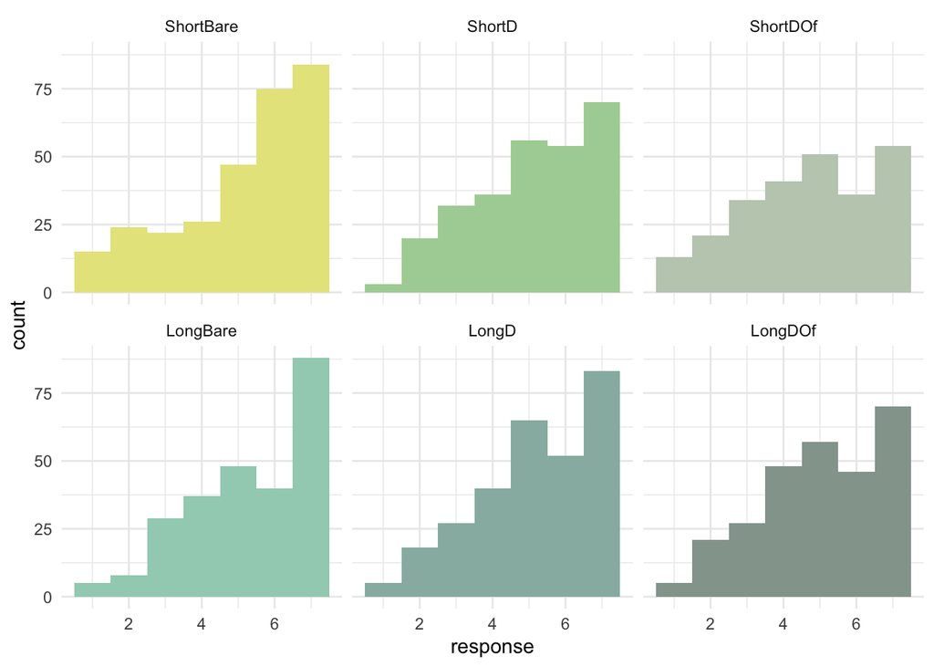

```r
ggplot(df.english.dlink, aes(response, fill=condition)) +
  scale_fill_ghibli_d("MarnieLight2", -1) +
  geom_histogram(binwidth = 1, show.legend=FALSE) +
  theme_minimal() +
  facet_wrap(.~condition)
```

#### Fillers

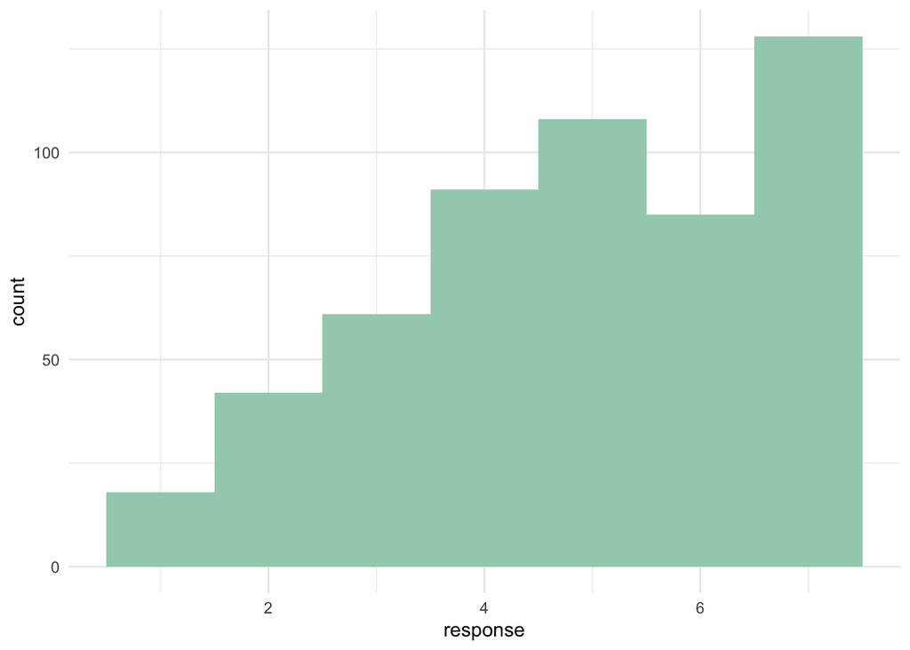

```r
ggplot(df.english.filler, aes(response, fill=filler)) +
  scale_fill_ghibli_c("MarnieLight2", -1) +
  geom_histogram(binwidth = 1, show.legend=FALSE) +
  theme_minimal()
```

### Z-scored responses

#### D-linking items

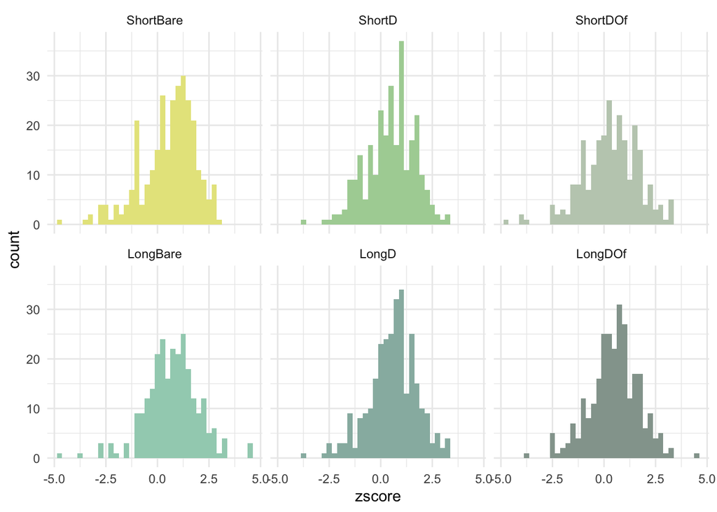

```r
ggplot(df.english.dlink, aes(zscore, fill=condition)) +
  scale_fill_ghibli_d("MarnieLight2", -1) +
  geom_histogram(binwidth = 0.25, show.legend=FALSE) +
  theme_minimal() +
  facet_wrap(.~condition)
```

#### Fillers

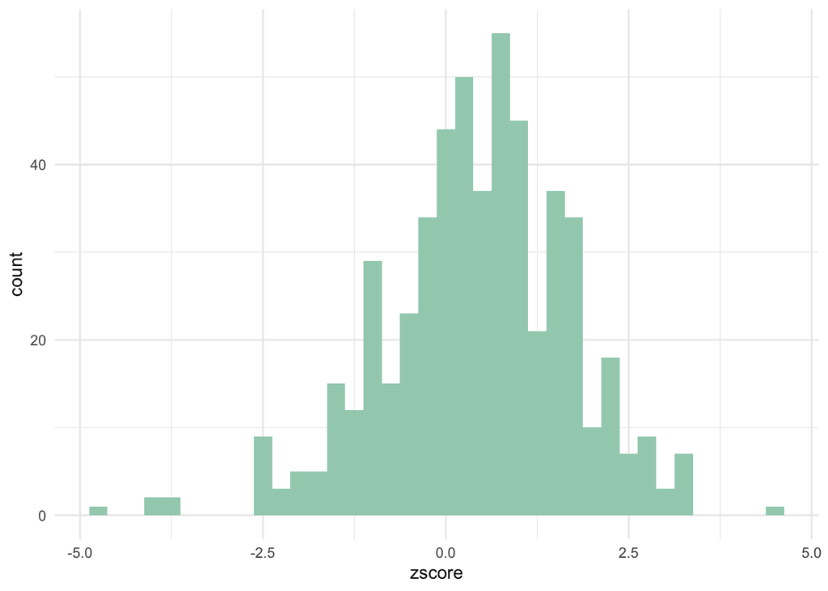

```r
ggplot(df.english.filler, aes(zscore, fill=filler)) +
  scale_fill_ghibli_c("MarnieLight2", -1) +
  geom_histogram(binwidth = 0.25, show.legend=FALSE) +
  theme_minimal()
```

## Density plots

And some density and violin plots for a cleaner visualization.

### D-linking items

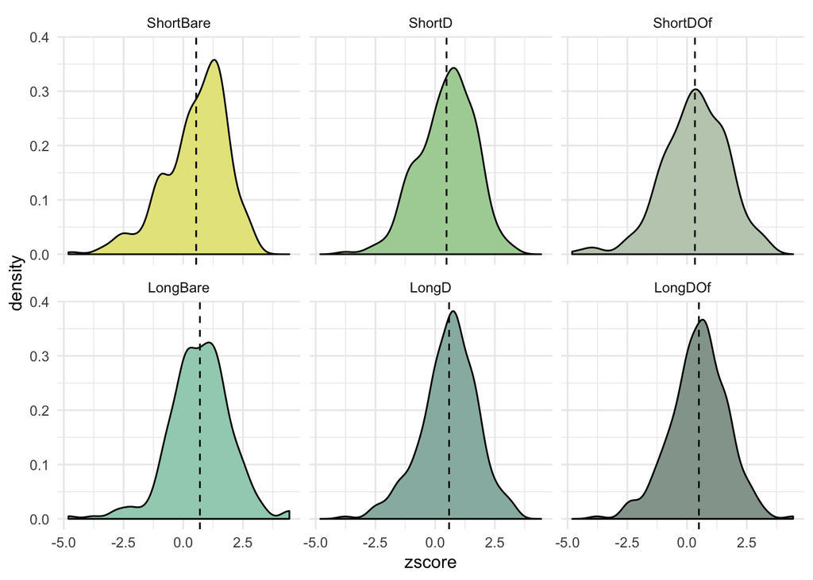

```r
ggplot(df.english.dlink, aes(zscore, fill=condition, group=condition)) +
  scale_fill_ghibli_d("MarnieLight2", -1) +
  geom_density(show.legend=FALSE) +
  theme_minimal() +
  geom_vline(data=(df.english.dlink %>% group_by(condition) %>% summarise(mean = mean(zscore))),
                        aes(xintercept=mean), linetype="dashed", size=0.5) +
  facet_wrap(.~condition)
```

### Fillers

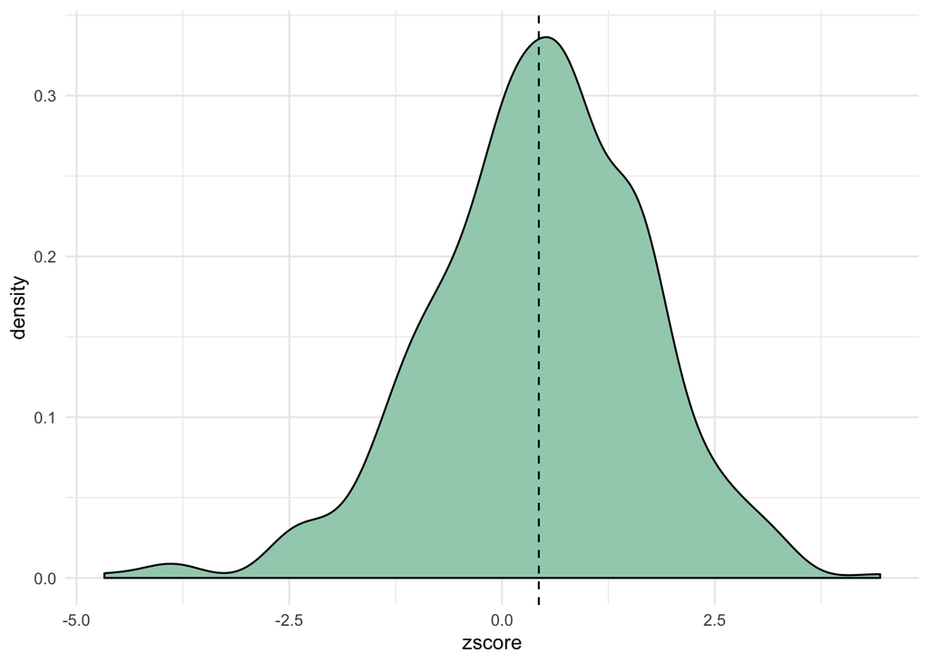

```r
ggplot(df.english.filler, aes(zscore, fill=filler)) +
  scale_fill_ghibli_c("MarnieLight2", -1) +
  geom_density(show.legend=F) +
  theme_minimal() +
  geom_vline(data=(df.english.filler %>% summarise(mean = mean(zscore))),
                        aes(xintercept=mean), linetype="dashed", size=0.5)
```

### Violin + dot plots

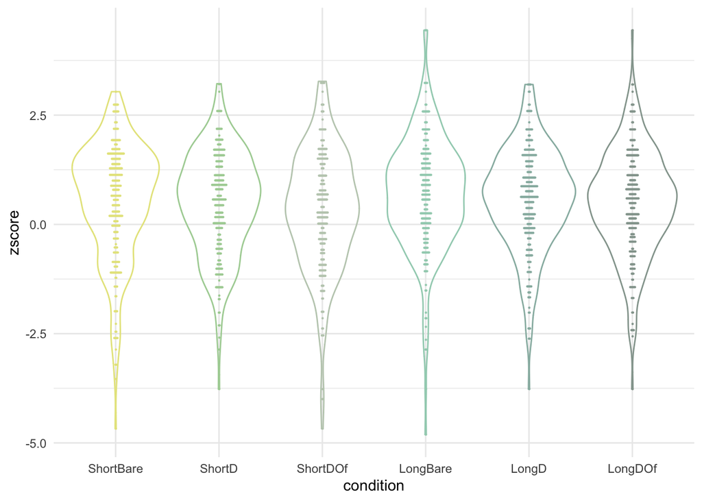

```r
ggplot(df.english.dlink, aes(x=condition, y=zscore, group=condition), show.legend = FALSE) +
  scale_fill_ghibli_d("MarnieLight2", -1) +
  scale_color_ghibli_d("MarnieLight2", -1) +
  theme_minimal() +
  geom_violin(aes(color=condition, fill=NA), show.legend = FALSE) +
  geom_dotplot(binaxis='y', stackdir='center', binwidth=0.1,
               stackratio=0.6, dotsize=0.3, aes(color=condition, fill=condition), show.legend = FALSE)
```

In order to do a proper 2x3, the data must be recoded, so we do that here.

```r
df.english.dlink <- df.english.dlink %>%
  mutate(distance=ifelse(
    condition=="ShortBare" | condition == "ShortD" | condition=="ShortDOf", "Short", "Long"),
    dlink=ifelse(
      condition=="ShortBare" | condition=="LongBare", "Bare",
      ifelse(condition=="ShortD" | condition=="LongD", "D", "DOf")
      ),
    dlinkBin=ifelse(
      condition=="ShortBare" | condition=="LongBare", "Bare", "DLink"
      )
    )

# Create factors
df.english.dlink$distance    <- factor(df.english.dlink$distance, levels=c("Short", "Long"))
df.english.dlink$dlink       <- factor(df.english.dlink$dlink, levels=c("Bare", "D", "DOf"))
df.english.dlink$dlinkBin    <- factor(df.english.dlink$dlinkBin, levels=c("Bare", "DLink"))

# Summaries
df.english.dlink %>% group_by(distance, dlink) %>% summarize(count=n(), mean=mean(zscore), sd=sd(zscore), se=sd / sqrt(count)) %>% ungroup()
```

```
## # A tibble: 6 x 6
##   distance dlink count  mean    sd     se
##   <fct>    <fct> <int> <dbl> <dbl>  <dbl>
## 1 Short    Bare    293 0.540  1.30 0.0762
## 2 Short    D       271 0.477  1.16 0.0706
## 3 Short    DOf     250 0.332  1.34 0.0850
## 4 Long     Bare    255 0.697  1.28 0.0801
## 5 Long     D       290 0.584  1.16 0.0678
## 6 Long     DOf     274 0.498  1.18 0.0710
```

```r
df.english.dlink %>% group_by(distance) %>% summarize(count=n(), mean=mean(zscore), sd=sd(zscore), se=sd / sqrt(count)) %>% ungroup()
```

```
## # A tibble: 2 x 5
##   distance count  mean    sd     se
##   <fct>    <int> <dbl> <dbl>  <dbl>
## 1 Short      814 0.455  1.27 0.0446
## 2 Long       819 0.590  1.20 0.0420
```

```r
df.english.dlink %>% group_by(dlink) %>% summarize(count=n(), mean=mean(zscore), sd=sd(zscore), se=sd / sqrt(count)) %>% ungroup()
```

```
## # A tibble: 3 x 5
##   dlink count  mean    sd     se
##   <fct> <int> <dbl> <dbl>  <dbl>
## 1 Bare    548 0.613  1.29 0.0553
## 2 D       561 0.533  1.16 0.0489
## 3 DOf     524 0.419  1.26 0.0550
```

## Interaction plots

Not much of a difference.

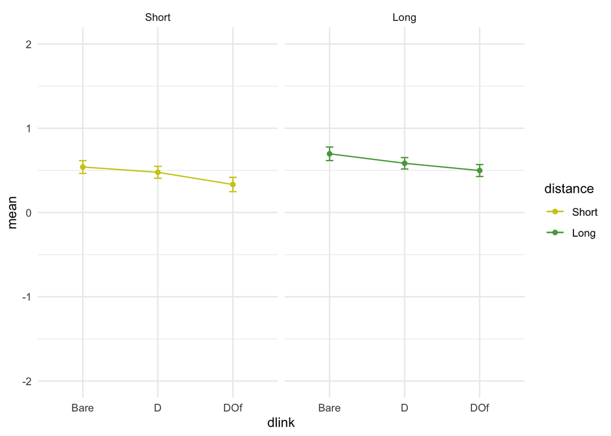

```r
df.english.dlink.summarized <- df.english.dlink %>% group_by(distance, dlink) %>% summarize(count=n(), mean=mean(zscore), sd=sd(zscore), se=sd / sqrt(count)) %>% ungroup()
ggplot(data=df.english.dlink.summarized, aes(x=dlink, y=mean, group=distance, color=distance)) +
  ylim(-2,2) +
  scale_color_ghibli_d("MarnieMedium2", -1) +
  geom_errorbar(aes(ymin=mean-se, ymax=mean+se), width=.1) +
  geom_point() +
  geom_line() +
  theme_minimal() +
  facet_wrap(.~distance)
```

## By-subject plots

Some subjects seem to be missing conditions.

### Short condition

```
## geom_path: Each group consists of only one observation. Do you need to adjust
## the group aesthetic?
## geom_path: Each group consists of only one observation. Do you need to adjust
## the group aesthetic?
```

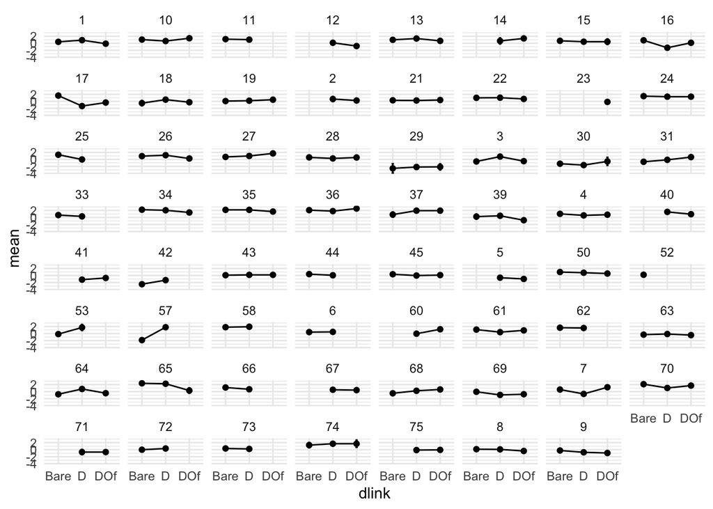

```r
df.english.dlink.summarizedShort <- df.english.dlink %>% filter(distance=="Short") %>% group_by(participant, dlink) %>% summarize(count=n(), mean=mean(zscore), sd=sd(zscore), se=sd / sqrt(count)) %>% ungroup()
ggplot(data=df.english.dlink.summarizedShort, aes(x=dlink, y=mean, group=participant)) +
  geom_errorbar(aes(ymin=mean-se, ymax=mean+se), width=.1) +
  geom_point() +
  geom_line() +
  theme_minimal() +
  facet_wrap(.~participant)
```

### Long condition

```
## geom_path: Each group consists of only one observation. Do you need to adjust
## the group aesthetic?
## geom_path: Each group consists of only one observation. Do you need to adjust
## the group aesthetic?
```

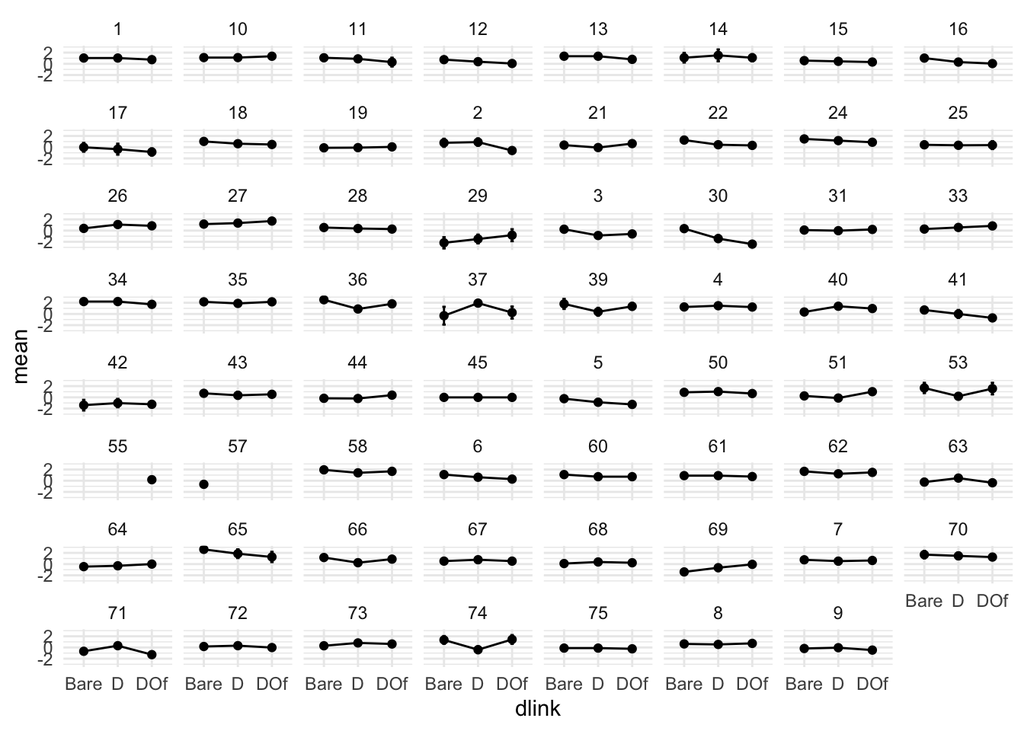

```r
df.english.dlink.summarizedLong <- df.english.dlink %>% filter(distance=="Long") %>% group_by(participant, dlink) %>% summarize(count=n(), mean=mean(zscore), sd=sd(zscore), se=sd / sqrt(count)) %>% ungroup()
ggplot(data=df.english.dlink.summarizedLong, aes(x=dlink, y=mean, group=participant)) +
  geom_errorbar(aes(ymin=mean-se, ymax=mean+se), width=.1) +
  geom_point() +
  geom_line() +
  theme_minimal() +
  facet_wrap(.~participant)
```

## By-item plots

Missing data here too.

### Short condition

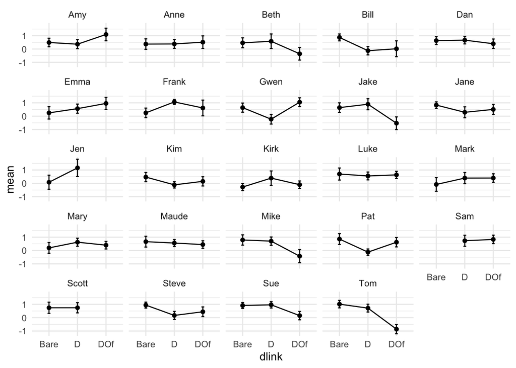

```r
df.english.dlink.summarizedShortI <- df.english.dlink %>% filter(distance=="Short") %>% group_by(itemText, dlink) %>% summarize(count=n(), mean=mean(zscore), sd=sd(zscore), se=sd / sqrt(count)) %>% ungroup()
ggplot(data=df.english.dlink.summarizedShortI, aes(x=dlink, y=mean, group=itemText)) +
  geom_errorbar(aes(ymin=mean-se, ymax=mean+se), width=.1) +
  geom_point() +
  geom_line() +
  theme_minimal() +
  facet_wrap(.~itemText)
```

### Long condition

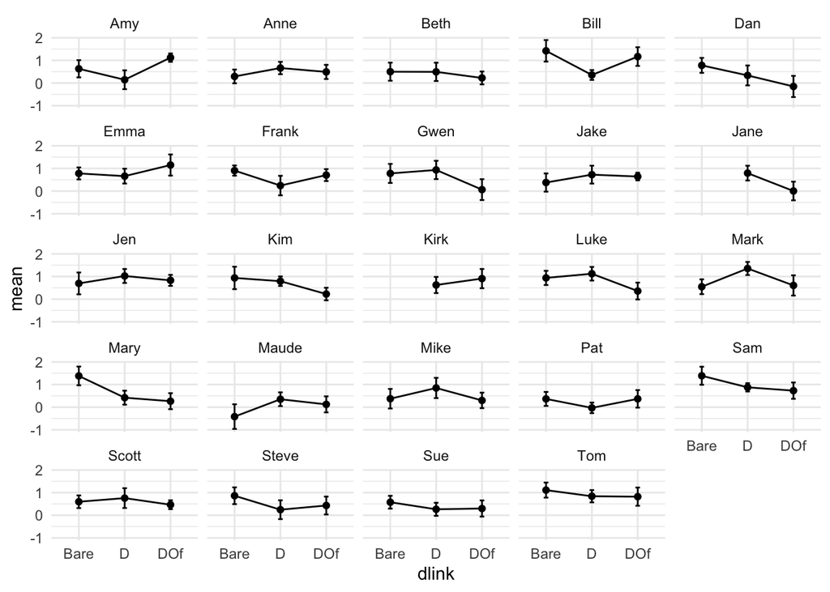

```r
df.english.dlink.summarizedLongI <- df.english.dlink %>% filter(distance=="Long") %>% group_by(itemText, dlink) %>% summarize(count=n(), mean=mean(zscore), sd=sd(zscore), se=sd / sqrt(count)) %>% ungroup()
ggplot(data=df.english.dlink.summarizedLongI, aes(x=dlink, y=mean, group=itemText)) +
  geom_errorbar(aes(ymin=mean-se, ymax=mean+se), width=.1) +
  geom_point() +
  geom_line() +
  theme_minimal() +
  facet_wrap(.~itemText)
```

## Mixed-effects model

Finally, we fit a linear mixed-effects regression. But I’m not actually sure what the plan was for data analysis, so it probably needs tweaking. At any rate, there are main effects of Dlinking and distance, but they’re in the wrong direction…

```r
# Define contrasts
contrasts(df.english.dlink$distance) <- cbind(c(-1, 1))
contrasts(df.english.dlink$dlink)    <- cbind(c(1, -1, 0), c(1, 1, -2))

# Alternative coding (unused)
#df.english.dlink <- df.english.dlink %>%
#  mutate(dlinkCont = ifelse(dlink=="Bare",-1,ifelse(dlink=="D", 0, 1)),
#         distCont = ifelse(distance=="Short", -1, 1))

# Linear mixed-effects
# Note: Currently won't converge with by-item intercepts

out.lmer <- lmer(zscore ~ distance*dlink + (1 | participant) + (1 | list), data=df.english.dlink)
summary(out.lmer)
```

```
## Linear mixed model fit by REML. t-tests use Satterthwaite's method [
## lmerModLmerTest]
## Formula: zscore ~ distance * dlink + (1 | participant) + (1 | list)
##    Data: df.english.dlink
##
## REML criterion at convergence: 4766.5
##
## Scaled residuals:
##     Min      1Q  Median      3Q     Max
## -6.0361 -0.5060  0.1114  0.5686  3.7477
##
## Random effects:
##  Groups      Name        Variance Std.Dev.
##  participant (Intercept) 0.7609   0.8723
##  list        (Intercept) 0.1395   0.3734
##  Residual                0.9460   0.9726
## Number of obs: 1633, groups:  participant, 65; list, 6
##
## Fixed effects:
##                    Estimate Std. Error         df t value Pr(>|t|)
## (Intercept)         0.47425    0.18977    8.65298   2.499 0.034897 *
## distance1           0.07719    0.02420 1552.61140   3.190 0.001451 **
## dlink1              0.04243    0.03018 1556.36846   1.406 0.160057
## dlink2              0.05820    0.01762 1557.10601   3.302 0.000981 ***
## distance1:dlink1    0.01496    0.03008 1556.21265   0.497 0.619167
## distance1:dlink2   -0.01065    0.01765 1557.20142  -0.603 0.546467
## ---
## Signif. codes:  0 '***' 0.001 '**' 0.01 '*' 0.05 '.' 0.1 ' ' 1
##
## Correlation of Fixed Effects:
##             (Intr) dstnc1 dlink1 dlink2 dst1:1
## distance1   -0.001
## dlink1      -0.004  0.035
## dlink2       0.000  0.030  0.000
## dstnc1:dln1  0.008  0.017 -0.036  0.021
## dstnc1:dln2  0.002 -0.026  0.033 -0.070  0.018
```